# seizure

Astrid

2022-09-29

# Addition for VAS

- Add the screening records (instance = 0)
- Show the interaction plot
- include the age(significant), city(significant) elements

```
##
## Call:
## lm(formula = qolie ~ factor(study_arm) * factor(redcap_repeat_instance) +
##     age + factor(city), data = vas)
##
## Residuals:
##     Min      1Q  Median      3Q     Max
## -81.081 -11.796  -0.628  12.662  50.710
##
## Coefficients:
##                                                       Estimate Std. Error
## (Intercept)                                           51.95230    1.34696
## factor(study_arm)TSC                                   3.78179    1.71165
## factor(redcap_repeat_instance)1                        3.91832    1.39245
## factor(redcap_repeat_instance)2                        6.95141    1.39472
## factor(redcap_repeat_instance)3                       11.49741    1.39658
## factor(redcap_repeat_instance)4                       15.22921    1.39906
## factor(redcap_repeat_instance)5                       19.38120    1.40135
## factor(redcap_repeat_instance)6                       23.86678    1.40231
## factor(redcap_repeat_instance)7                       27.35362    1.40998
## factor(redcap_repeat_instance)8                       31.85021    1.40993
## factor(redcap_repeat_instance)9                       31.19976    1.42393
## factor(redcap_repeat_instance)10                      27.55208    2.50225
## age                                                    0.08381    0.03139
## factor(city)Kano                                      -5.56117    0.35831
## factor(city)Zaria                                     -6.97498    0.41016
## factor(study_arm)TSC:factor(redcap_repeat_instance)1   2.67866    1.90701
## factor(study_arm)TSC:factor(redcap_repeat_instance)2   6.35809    1.91274
## factor(study_arm)TSC:factor(redcap_repeat_instance)3   5.28366    1.91903
## factor(study_arm)TSC:factor(redcap_repeat_instance)4   5.94260    1.92065
## factor(study_arm)TSC:factor(redcap_repeat_instance)5   4.50686    1.92387
## factor(study_arm)TSC:factor(redcap_repeat_instance)6   4.13578    1.92492
## factor(study_arm)TSC:factor(redcap_repeat_instance)7   3.60696    1.93387
## factor(study_arm)TSC:factor(redcap_repeat_instance)8   3.61620    1.93585
## factor(study_arm)TSC:factor(redcap_repeat_instance)9   5.21671    1.95740
## factor(study_arm)TSC:factor(redcap_repeat_instance)10 15.59461    3.27423
##                                                       t value Pr(>|t|)
## (Intercept)                                            38.570  < 2e-16 ***
## factor(study_arm)TSC                                    2.209 0.027160 *
## factor(redcap_repeat_instance)1                         2.814 0.004900 **
```

[output cut: 14 more lines]

```
## factor(study_arm)TSC:factor(redcap_repeat_instance)3    2.753 0.005907 **
## factor(study_arm)TSC:factor(redcap_repeat_instance)4    3.094 0.001978 **
## factor(study_arm)TSC:factor(redcap_repeat_instance)5    2.343 0.019163 *
## factor(study_arm)TSC:factor(redcap_repeat_instance)6    2.149 0.031687 *
## factor(study_arm)TSC:factor(redcap_repeat_instance)7    1.865 0.062180 .
## factor(study_arm)TSC:factor(redcap_repeat_instance)8    1.868 0.061780 .
## factor(study_arm)TSC:factor(redcap_repeat_instance)9    2.665 0.007705 **
## factor(study_arm)TSC:factor(redcap_repeat_instance)10   4.763 1.93e-06 ***
## ---
## Signif. codes:  0 '***' 0.001 '**' 0.01 '*' 0.05 '.' 0.1 ' ' 1
##
## Residual standard error: 17.14 on 14156 degrees of freedom
##   (777 observations deleted due to missingness)
## Multiple R-squared:  0.3073, Adjusted R-squared:  0.3061
## F-statistic: 261.6 on 24 and 14156 DF,  p-value: < 2.2e-16
```

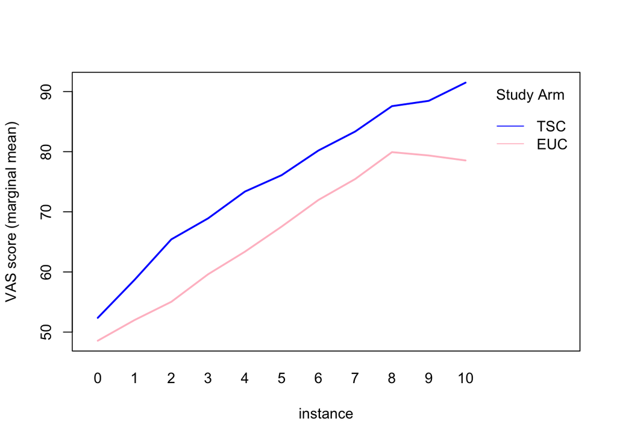

# What kind of dependent variables can we use?

- Binomial question: 0 for No, 1 for Yes
  - diagnosis_of_seizures: confirmseize
  - weakness
  - tremor_present_v2
  - development delay: nodelays (for original question, 0 for no, 1 - 5 for classification)
  - development regression: dev_regression_v2
- Categorical Question: no sure is there any ranks between the categories
  - seizure classification: seizeclass
- Continuous Question
  - how many times of experienced seizures since last visit: TSC – expseiz + how_many_seiz_v2, EUC – seize_since_last_euc_v2 + number_seiz
  - how many times of experienced prolonged seizures: TSC - prolonged_seiz_v2 + how_many_prolonged_v2, EUC - prolonged_euc_v2 + number_prolonged_euc_v2

## Binomial Questions

Development delay question shows kind of interaction, devolopment regression questions shows kind of main effect of instances.

```
##
## Call:
## glm(formula = confirmseize ~ factor(study_arm) * factor(redcap_repeat_instance),
##     family = "binomial", data = fcf_c %>% filter(confirmseize !=
##         2))
##
## Deviance Residuals:
##     Min       1Q   Median       3Q      Max
## -3.6588   0.0000   0.0512   0.1329   0.2156
##
## Coefficients:
##                                                         Estimate Std. Error
## (Intercept)                                            2.157e+01  1.012e+03
## factor(study_arm)TSC                                   1.132e-07  1.429e+03
## factor(redcap_repeat_instance)2                        5.303e-08  1.441e+03
## factor(redcap_repeat_instance)3                        6.186e-08  1.447e+03
## factor(redcap_repeat_instance)4                        6.400e-08  1.455e+03
## factor(redcap_repeat_instance)5                        8.013e-08  1.463e+03
## factor(redcap_repeat_instance)6                       -1.494e+01  1.012e+03
## factor(redcap_repeat_instance)7                       -1.566e+01  1.012e+03
## factor(redcap_repeat_instance)8                       -1.677e+01  1.012e+03
## factor(redcap_repeat_instance)9                       -1.684e+01  1.012e+03
## factor(redcap_repeat_instance)10                      -1.672e+01  1.012e+03
## factor(study_arm)TSC:factor(redcap_repeat_instance)2  -1.487e+01  1.758e+03
## factor(study_arm)TSC:factor(redcap_repeat_instance)3  -1.492e+01  1.764e+03
## factor(study_arm)TSC:factor(redcap_repeat_instance)4  -1.492e+01  1.770e+03
## factor(study_arm)TSC:factor(redcap_repeat_instance)5  -1.493e+01  1.777e+03
## factor(study_arm)TSC:factor(redcap_repeat_instance)6  -2.078e+00  1.429e+03
## factor(study_arm)TSC:factor(redcap_repeat_instance)7  -1.838e+00  1.429e+03
## factor(study_arm)TSC:factor(redcap_repeat_instance)8  -1.041e+00  1.429e+03
## factor(study_arm)TSC:factor(redcap_repeat_instance)9  -8.326e-01  1.429e+03
## factor(study_arm)TSC:factor(redcap_repeat_instance)10 -3.524e-01  1.429e+03
##                                                       z value Pr(>|z|)
## (Intercept)                                             0.021    0.983
## factor(study_arm)TSC                                    0.000    1.000
## factor(redcap_repeat_instance)2                         0.000    1.000
## factor(redcap_repeat_instance)3                         0.000    1.000
## factor(redcap_repeat_instance)4                         0.000    1.000
## factor(redcap_repeat_instance)5                         0.000    1.000
## factor(redcap_repeat_instance)6                        -0.015    0.988
## factor(redcap_repeat_instance)7                        -0.015    0.988
## factor(redcap_repeat_instance)8                        -0.017    0.987
## factor(redcap_repeat_instance)9                        -0.017    0.987
## factor(redcap_repeat_instance)10                       -0.017    0.987
## factor(study_arm)TSC:factor(redcap_repeat_instance)2   -0.008    0.993
## factor(study_arm)TSC:factor(redcap_repeat_instance)3   -0.008    0.993
## factor(study_arm)TSC:factor(redcap_repeat_instance)4   -0.008    0.993
## factor(study_arm)TSC:factor(redcap_repeat_instance)5   -0.008    0.993
## factor(study_arm)TSC:factor(redcap_repeat_instance)6   -0.001    0.999
## factor(study_arm)TSC:factor(redcap_repeat_instance)7   -0.001    0.999
## factor(study_arm)TSC:factor(redcap_repeat_instance)8   -0.001    0.999
## factor(study_arm)TSC:factor(redcap_repeat_instance)9   -0.001    1.000
## factor(study_arm)TSC:factor(redcap_repeat_instance)10   0.000    1.000
##
## (Dispersion parameter for binomial family taken to be 1)
##
##     Null deviance: 971.67  on 14588  degrees of freedom
## Residual deviance: 841.78  on 14569  degrees of freedom
## AIC: 881.78
##
## Number of Fisher Scoring iterations: 20
```

```
##
## Call:
## glm(formula = weakness ~ factor(study_arm) * factor(redcap_repeat_instance),
##     family = "binomial", data = fcf_c)
##
## Deviance Residuals:
##     Min       1Q   Median       3Q      Max
## -0.6148  -0.5757  -0.5521  -0.5278   2.0757
##
## Coefficients:
##                                                       Estimate Std. Error
## (Intercept)                                           -1.63413    0.09374
## factor(study_arm)TSC                                   0.06408    0.13084
## factor(redcap_repeat_instance)2                       -0.03255    0.13418
## factor(redcap_repeat_instance)3                       -0.12873    0.13712
## factor(redcap_repeat_instance)4                       -0.09196    0.13701
## factor(redcap_repeat_instance)5                       -0.12742    0.13874
## factor(redcap_repeat_instance)6                       -0.13023    0.13907
## factor(redcap_repeat_instance)7                       -0.07943    0.13868
## factor(redcap_repeat_instance)8                       -0.11507    0.14020
## factor(redcap_repeat_instance)9                       -0.18531    0.14498
## factor(redcap_repeat_instance)10                      -0.07829    0.16969
## factor(study_arm)TSC:factor(redcap_repeat_instance)2  -0.08174    0.18906
## factor(study_arm)TSC:factor(redcap_repeat_instance)3  -0.10514    0.19447
## factor(study_arm)TSC:factor(redcap_repeat_instance)4  -0.23313    0.19619
## factor(study_arm)TSC:factor(redcap_repeat_instance)5  -0.27572    0.19957
## factor(study_arm)TSC:factor(redcap_repeat_instance)6  -0.18589    0.19767
## factor(study_arm)TSC:factor(redcap_repeat_instance)7  -0.38159    0.20033
## factor(study_arm)TSC:factor(redcap_repeat_instance)8  -0.17118    0.19887
## factor(study_arm)TSC:factor(redcap_repeat_instance)9  -0.14559    0.20490
## factor(study_arm)TSC:factor(redcap_repeat_instance)10 -0.20923    0.24641
##                                                       z value Pr(>|z|)
## (Intercept)                                           -17.432   <2e-16 ***
## factor(study_arm)TSC                                    0.490   0.6243
## factor(redcap_repeat_instance)2                        -0.243   0.8083
## factor(redcap_repeat_instance)3                        -0.939   0.3478
## factor(redcap_repeat_instance)4                        -0.671   0.5021
## factor(redcap_repeat_instance)5                        -0.918   0.3584
## factor(redcap_repeat_instance)6                        -0.936   0.3490
## factor(redcap_repeat_instance)7                        -0.573   0.5668
```

[output cut: 8 more lines]

```
## factor(study_arm)TSC:factor(redcap_repeat_instance)7   -1.905   0.0568 .
## factor(study_arm)TSC:factor(redcap_repeat_instance)8   -0.861   0.3894
## factor(study_arm)TSC:factor(redcap_repeat_instance)9   -0.711   0.4773
## factor(study_arm)TSC:factor(redcap_repeat_instance)10  -0.849   0.3958
## ---
## Signif. codes:  0 '***' 0.001 '**' 0.01 '*' 0.05 '.' 0.1 ' ' 1
##
## (Dispersion parameter for binomial family taken to be 1)
##
##     Null deviance: 12032  on 14582  degrees of freedom
## Residual deviance: 12008  on 14563  degrees of freedom
##   (9 observations deleted due to missingness)
## AIC: 12048
##
## Number of Fisher Scoring iterations: 4
```

```
##
## Call:
## glm(formula = tremor_present_v2 ~ factor(study_arm) * factor(redcap_repeat_instance),
##     family = "binomial", data = fcf_c)
##
## Deviance Residuals:
##     Min       1Q   Median       3Q      Max
## -0.1705  -0.1042  -0.0720  -0.0487   3.6707
##
## Coefficients:
##                                                        Estimate Std. Error
## (Intercept)                                             -4.2244     0.2908
## factor(study_arm)TSC                                    -2.5114     1.0420
## factor(redcap_repeat_instance)2                         -0.8582     0.5346
## factor(redcap_repeat_instance)3                         -0.6559     0.5025
## factor(redcap_repeat_instance)4                         -1.3350     0.6474
## factor(redcap_repeat_instance)5                         -1.0226     0.5795
## factor(redcap_repeat_instance)6                         -1.0120     0.5796
## factor(redcap_repeat_instance)7                         -0.9892     0.5796
## factor(redcap_repeat_instance)8                         -1.2645     0.6475
## factor(redcap_repeat_instance)9                         -0.9085     0.5797
## factor(redcap_repeat_instance)10                        -0.3295     0.5807
## factor(study_arm)TSC:factor(redcap_repeat_instance)2     1.5988     1.3372
## factor(study_arm)TSC:factor(redcap_repeat_instance)3     0.7453     1.5017
## factor(study_arm)TSC:factor(redcap_repeat_instance)4     2.1162     1.3862
## factor(study_arm)TSC:factor(redcap_repeat_instance)5     1.1225     1.5292
## factor(study_arm)TSC:factor(redcap_repeat_instance)6   -13.8182  1055.5228
## factor(study_arm)TSC:factor(redcap_repeat_instance)7   -13.8411  1049.3840
## factor(study_arm)TSC:factor(redcap_repeat_instance)8   -13.5657  1075.3333
## factor(study_arm)TSC:factor(redcap_repeat_instance)9   -13.9218  1106.4647
## factor(study_arm)TSC:factor(redcap_repeat_instance)10  -14.5008  1536.4233
##                                                       z value Pr(>|z|)
## (Intercept)                                           -14.528   <2e-16 ***
## factor(study_arm)TSC                                   -2.410   0.0159 *
## factor(redcap_repeat_instance)2                        -1.605   0.1084
## factor(redcap_repeat_instance)3                        -1.305   0.1918
## factor(redcap_repeat_instance)4                        -2.062   0.0392 *
## factor(redcap_repeat_instance)5                        -1.765   0.0776 .
## factor(redcap_repeat_instance)6                        -1.746   0.0808 .
## factor(redcap_repeat_instance)7                        -1.707   0.0879 .
```

[output cut: 8 more lines]

```
## factor(study_arm)TSC:factor(redcap_repeat_instance)7   -0.013   0.9895
## factor(study_arm)TSC:factor(redcap_repeat_instance)8   -0.013   0.9899
## factor(study_arm)TSC:factor(redcap_repeat_instance)9   -0.013   0.9900
## factor(study_arm)TSC:factor(redcap_repeat_instance)10  -0.009   0.9925
## ---
## Signif. codes:  0 '***' 0.001 '**' 0.01 '*' 0.05 '.' 0.1 ' ' 1
##
## (Dispersion parameter for binomial family taken to be 1)
##
##     Null deviance: 734.67  on 14571  degrees of freedom
## Residual deviance: 680.39  on 14552  degrees of freedom
##   (20 observations deleted due to missingness)
## AIC: 720.39
##
## Number of Fisher Scoring iterations: 20
```

```
##
## Call:
## glm(formula = delays ~ factor(study_arm) * factor(redcap_repeat_instance),
##     family = "binomial", data = fcf_c %>% mutate(delays = ifelse(nodelays ==
##         0, 1, 0)))
##
## Deviance Residuals:
##     Min       1Q   Median       3Q      Max
## -0.9278  -0.7983  -0.7545   1.5132   1.7109
##
## Coefficients:
##                                                        Estimate Std. Error
## (Intercept)                                           -0.953520   0.077275
## factor(study_arm)TSC                                  -0.124635   0.110608
## factor(redcap_repeat_instance)2                        0.017341   0.109775
## factor(redcap_repeat_instance)3                       -0.026736   0.110814
## factor(redcap_repeat_instance)4                       -0.042011   0.111634
## factor(redcap_repeat_instance)5                       -0.182036   0.114346
## factor(redcap_repeat_instance)6                        0.018710   0.111710
## factor(redcap_repeat_instance)7                        0.182305   0.110550
## factor(redcap_repeat_instance)8                        0.191667   0.110878
## factor(redcap_repeat_instance)9                        0.143649   0.113367
## factor(redcap_repeat_instance)10                       0.333342   0.131768
## factor(study_arm)TSC:factor(redcap_repeat_instance)2  -0.022983   0.157714
## factor(study_arm)TSC:factor(redcap_repeat_instance)3  -0.012836   0.159771
## factor(study_arm)TSC:factor(redcap_repeat_instance)4  -0.036205   0.160720
## factor(study_arm)TSC:factor(redcap_repeat_instance)5   0.149309   0.162391
## factor(study_arm)TSC:factor(redcap_repeat_instance)6  -0.002988   0.159914
## factor(study_arm)TSC:factor(redcap_repeat_instance)7  -0.251467   0.159779
## factor(study_arm)TSC:factor(redcap_repeat_instance)8  -0.241165   0.160843
## factor(study_arm)TSC:factor(redcap_repeat_instance)9  -0.133858   0.163158
## factor(study_arm)TSC:factor(redcap_repeat_instance)10 -0.455582   0.197774
##                                                       z value Pr(>|z|)
## (Intercept)                                           -12.339   <2e-16 ***
## factor(study_arm)TSC                                   -1.127   0.2598
## factor(redcap_repeat_instance)2                         0.158   0.8745
## factor(redcap_repeat_instance)3                        -0.241   0.8093
## factor(redcap_repeat_instance)4                        -0.376   0.7067
## factor(redcap_repeat_instance)5                        -1.592   0.1114
## factor(redcap_repeat_instance)6                         0.167   0.8670
```

[output cut: 8 more lines]

```
## factor(study_arm)TSC:factor(redcap_repeat_instance)6   -0.019   0.9851
## factor(study_arm)TSC:factor(redcap_repeat_instance)7   -1.574   0.1155
## factor(study_arm)TSC:factor(redcap_repeat_instance)8   -1.499   0.1338
## factor(study_arm)TSC:factor(redcap_repeat_instance)9   -0.820   0.4120
## factor(study_arm)TSC:factor(redcap_repeat_instance)10  -2.304   0.0212 *
## ---
## Signif. codes:  0 '***' 0.001 '**' 0.01 '*' 0.05 '.' 0.1 ' ' 1
##
## (Dispersion parameter for binomial family taken to be 1)
##
##     Null deviance: 16964  on 14591  degrees of freedom
## Residual deviance: 16907  on 14572  degrees of freedom
## AIC: 16947
##
## Number of Fisher Scoring iterations: 4
```

```
##
## Call:
## glm(formula = dev_regression_v2 ~ factor(study_arm) * factor(redcap_repeat_instance),
##     family = "binomial", data = fcf_c %>% filter(dev_regression_v2 !=
##         2))
##
## Deviance Residuals:
##     Min       1Q   Median       3Q      Max
## -0.3158  -0.2664  -0.1704  -0.1474   3.2455
##
## Coefficients:
##                                                       Estimate Std. Error
## (Intercept)                                           -3.18560    0.17764
## factor(study_arm)TSC                                   0.21206    0.23915
## factor(redcap_repeat_instance)2                       -0.07378    0.25724
## factor(redcap_repeat_instance)3                       -0.47411    0.28782
## factor(redcap_repeat_instance)4                       -1.38653    0.39730
## factor(redcap_repeat_instance)5                       -0.87086    0.33138
## factor(redcap_repeat_instance)6                       -1.23458    0.37948
## factor(redcap_repeat_instance)7                       -1.33074    0.39739
## factor(redcap_repeat_instance)8                       -0.81893    0.33148
## factor(redcap_repeat_instance)9                       -1.24819    0.39754
## factor(redcap_repeat_instance)10                      -1.66121    0.60619
## factor(study_arm)TSC:factor(redcap_repeat_instance)2  -0.27335    0.35890
## factor(study_arm)TSC:factor(redcap_repeat_instance)3   0.20829    0.37989
## factor(study_arm)TSC:factor(redcap_repeat_instance)4   0.43743    0.50147
## factor(study_arm)TSC:factor(redcap_repeat_instance)5  -0.38045    0.47717
## factor(study_arm)TSC:factor(redcap_repeat_instance)6  -1.04154    0.64857
## factor(study_arm)TSC:factor(redcap_repeat_instance)7  -0.95712    0.65919
## factor(study_arm)TSC:factor(redcap_repeat_instance)8  -0.60472    0.49799
## factor(study_arm)TSC:factor(redcap_repeat_instance)9  -0.01238    0.53397
## factor(study_arm)TSC:factor(redcap_repeat_instance)10  0.36365    0.77195
##                                                       z value Pr(>|z|)
## (Intercept)                                           -17.933  < 2e-16 ***
## factor(study_arm)TSC                                    0.887 0.375220
## factor(redcap_repeat_instance)2                        -0.287 0.774260
## factor(redcap_repeat_instance)3                        -1.647 0.099516 .
## factor(redcap_repeat_instance)4                        -3.490 0.000483 ***
## factor(redcap_repeat_instance)5                        -2.628 0.008589 **
## factor(redcap_repeat_instance)6                        -3.253 0.001141 **
```

[output cut: 8 more lines]

```
## factor(study_arm)TSC:factor(redcap_repeat_instance)6   -1.606 0.108296
## factor(study_arm)TSC:factor(redcap_repeat_instance)7   -1.452 0.146510
## factor(study_arm)TSC:factor(redcap_repeat_instance)8   -1.214 0.224627
## factor(study_arm)TSC:factor(redcap_repeat_instance)9   -0.023 0.981499
## factor(study_arm)TSC:factor(redcap_repeat_instance)10   0.471 0.637583
## ---
## Signif. codes:  0 '***' 0.001 '**' 0.01 '*' 0.05 '.' 0.1 ' ' 1
##
## (Dispersion parameter for binomial family taken to be 1)
##
##     Null deviance: 2931.3  on 14569  degrees of freedom
## Residual deviance: 2816.6  on 14550  degrees of freedom
## AIC: 2856.6
##
## Number of Fisher Scoring iterations: 7
```

## Times of seizures experienced since last visit

There’s effect from age and city.

```
##
## Call:
## lm(formula = seiz_freq ~ factor(study_arm) * factor(redcap_repeat_instance) +
##     agefu + factor(gender) + factor(city), data = seizure_times)
##
## Residuals:
##    Min     1Q Median     3Q    Max
## -379.4  -16.6   -6.1    4.3 3516.5
##
## Coefficients:
##                                                        Estimate Std. Error
## (Intercept)                                            118.6747     3.6584
## factor(study_arm)TSC                                   -47.8874     4.1447
## factor(redcap_repeat_instance)2                        -80.3261     4.2122
## factor(redcap_repeat_instance)3                        -96.0533     4.2368
## factor(redcap_repeat_instance)4                       -108.8718     4.2781
## factor(redcap_repeat_instance)5                       -108.9125     4.2975
## factor(redcap_repeat_instance)6                       -114.8956     4.2954
## factor(redcap_repeat_instance)7                       -114.5808     4.3350
## factor(redcap_repeat_instance)8                       -115.3473     4.3486
## factor(redcap_repeat_instance)9                       -114.6017     4.4452
## factor(redcap_repeat_instance)10                      -123.3646    11.0957
## agefu                                                   -0.4716     0.1577
## factor(gender)2                                          2.1735     1.5246
## factor(city)Kano                                         7.9922     1.8199
## factor(city)Zaria                                       15.5135     2.0807
## factor(study_arm)TSC:factor(redcap_repeat_instance)2    39.6209     5.9551
## factor(study_arm)TSC:factor(redcap_repeat_instance)3    44.2695     6.0120
## factor(study_arm)TSC:factor(redcap_repeat_instance)4    46.5230     6.0599
## factor(study_arm)TSC:factor(redcap_repeat_instance)5    46.1246     6.0727
## factor(study_arm)TSC:factor(redcap_repeat_instance)6    47.2895     6.0690
## factor(study_arm)TSC:factor(redcap_repeat_instance)7    46.0407     6.1107
## factor(study_arm)TSC:factor(redcap_repeat_instance)8    45.2335     6.1077
## factor(study_arm)TSC:factor(redcap_repeat_instance)9    44.8687     6.2465
## factor(study_arm)TSC:factor(redcap_repeat_instance)10   44.5146    14.4245
##                                                       t value Pr(>|t|)
## (Intercept)                                            32.439  < 2e-16 ***
## factor(study_arm)TSC                                  -11.554  < 2e-16 ***
## factor(redcap_repeat_instance)2                       -19.070  < 2e-16 ***
## factor(redcap_repeat_instance)3                       -22.671  < 2e-16 ***
```

[output cut: 12 more lines]

```
## factor(study_arm)TSC:factor(redcap_repeat_instance)3    7.364 1.90e-13 ***
## factor(study_arm)TSC:factor(redcap_repeat_instance)4    7.677 1.74e-14 ***
## factor(study_arm)TSC:factor(redcap_repeat_instance)5    7.595 3.27e-14 ***
## factor(study_arm)TSC:factor(redcap_repeat_instance)6    7.792 7.09e-15 ***
## factor(study_arm)TSC:factor(redcap_repeat_instance)7    7.534 5.22e-14 ***
## factor(study_arm)TSC:factor(redcap_repeat_instance)8    7.406 1.38e-13 ***
## factor(study_arm)TSC:factor(redcap_repeat_instance)9    7.183 7.19e-13 ***
## factor(study_arm)TSC:factor(redcap_repeat_instance)10   3.086  0.00203 **
## ---
## Signif. codes:  0 '***' 0.001 '**' 0.01 '*' 0.05 '.' 0.1 ' ' 1
##
## Residual standard error: 83.89 on 13176 degrees of freedom
##   (773 observations deleted due to missingness)
## Multiple R-squared:  0.1239, Adjusted R-squared:  0.1223
## F-statistic: 80.98 on 23 and 13176 DF,  p-value: < 2.2e-16
```

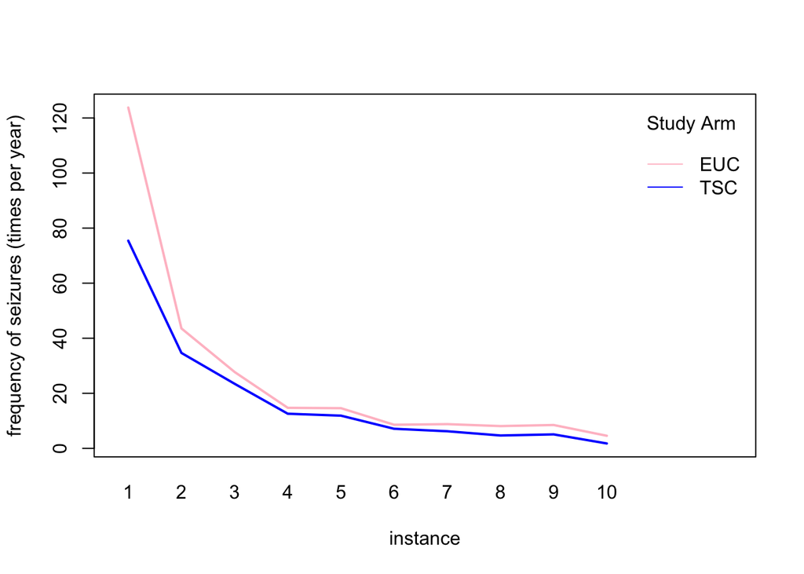

## Times of prolonged seizures experienced since last visit

No effect from age, city and gender.

```
##
## Call:
## lm(formula = prol_freq ~ factor(study_arm) * factor(redcap_repeat_instance) +
##     agefu + factor(gender) + factor(city), data = prolonged_times)
##
## Residuals:
##     Min      1Q  Median      3Q     Max
##  -13.49   -1.86   -0.68   -0.06 1038.57
##
## Coefficients:
##                                                        Estimate Std. Error
## (Intercept)                                            13.44767    0.94735
## factor(study_arm)TSC                                   -8.09867    1.07521
## factor(redcap_repeat_instance)2                        -8.27378    1.09252
## factor(redcap_repeat_instance)3                       -10.24905    1.09934
## factor(redcap_repeat_instance)4                       -11.26523    1.10770
## factor(redcap_repeat_instance)5                       -11.46063    1.11482
## factor(redcap_repeat_instance)6                       -12.03611    1.11346
## factor(redcap_repeat_instance)7                       -11.81992    1.12375
## factor(redcap_repeat_instance)8                       -11.75757    1.12775
## factor(redcap_repeat_instance)9                       -11.89232    1.15291
## factor(redcap_repeat_instance)10                      -11.63670    2.92092
## agefu                                                  -0.07853    0.04091
## factor(gender)2                                        -0.17801    0.39575
## factor(city)Kano                                        0.10009    0.47196
## factor(city)Zaria                                      -0.84341    0.54011
## factor(study_arm)TSC:factor(redcap_repeat_instance)2    5.92711    1.54588
## factor(study_arm)TSC:factor(redcap_repeat_instance)3    6.36988    1.56128
## factor(study_arm)TSC:factor(redcap_repeat_instance)4    7.07379    1.57149
## factor(study_arm)TSC:factor(redcap_repeat_instance)5    7.28475    1.57624
## factor(study_arm)TSC:factor(redcap_repeat_instance)6    7.83341    1.57472
## factor(study_arm)TSC:factor(redcap_repeat_instance)7    7.63659    1.58553
## factor(study_arm)TSC:factor(redcap_repeat_instance)8    7.70998    1.58449
## factor(study_arm)TSC:factor(redcap_repeat_instance)9    7.73960    1.62121
## factor(study_arm)TSC:factor(redcap_repeat_instance)10   8.63833    3.79030
##                                                       t value Pr(>|t|)
## (Intercept)                                            14.195  < 2e-16 ***
## factor(study_arm)TSC                                   -7.532 5.32e-14 ***
## factor(redcap_repeat_instance)2                        -7.573 3.89e-14 ***
## factor(redcap_repeat_instance)3                        -9.323  < 2e-16 ***
```

[output cut: 12 more lines]

```
## factor(study_arm)TSC:factor(redcap_repeat_instance)3    4.080 4.53e-05 ***
## factor(study_arm)TSC:factor(redcap_repeat_instance)4    4.501 6.81e-06 ***
## factor(study_arm)TSC:factor(redcap_repeat_instance)5    4.622 3.84e-06 ***
## factor(study_arm)TSC:factor(redcap_repeat_instance)6    4.974 6.62e-07 ***
## factor(study_arm)TSC:factor(redcap_repeat_instance)7    4.816 1.48e-06 ***
## factor(study_arm)TSC:factor(redcap_repeat_instance)8    4.866 1.15e-06 ***
## factor(study_arm)TSC:factor(redcap_repeat_instance)9    4.774 1.83e-06 ***
## factor(study_arm)TSC:factor(redcap_repeat_instance)10   2.279 0.022679 *
## ---
## Signif. codes:  0 '***' 0.001 '**' 0.01 '*' 0.05 '.' 0.1 ' ' 1
##
## Residual standard error: 21.75 on 13148 degrees of freedom
##   (771 observations deleted due to missingness)
## Multiple R-squared:  0.01986,    Adjusted R-squared:  0.01814
## F-statistic: 11.58 on 23 and 13148 DF,  p-value: < 2.2e-16
```

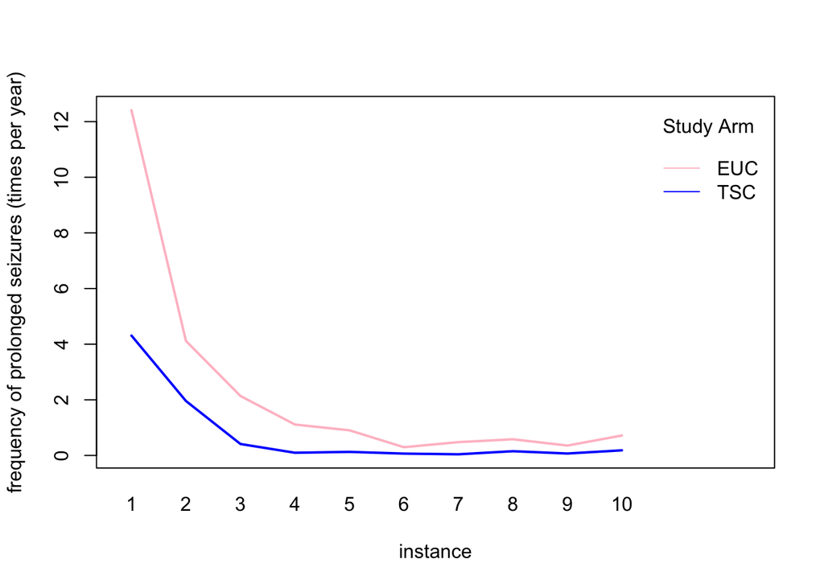

# Next step

- Should we delete the dropped-out participants from our analysis? Included or excluded their existing cases?
  - maybe just 2 versions and compares
- After the Bangkok trip, recheck all the important results with the updated datasets
- Any info about the other OUD project?